# Inference

Shammunul Islam

September 30, 2018

### Inference

“Statistical inference is the process of using data analysis to deduce properties of an underlying probability distribution.”

Before understanding inference, we need to understand population and sample.

#### Population

A set of similar items or events which of interest for some question or experiment.

#### Sample

A subset of population using which we answer the question of interest.

In making inference, we first make assumption, then we take sample data and analyze.

The first step of inference is making assumption or making hypothesis. There are two types of hypothesis.

- Null hypothesis (H0): There is no effect/there is no association. A statement which we are not interested in.
- Alternative hypothesis (HA): The effect/the relationship or the statement we are interested in to investigate.

### Testing change in proportion

```r
library(dplyr)
val = data.frame(
  admission = c(rep("admitted", 35), rep("not_admitteted", 13)),
              race = c(rep("white", 21), rep("black", 14), rep("white", 3), rep("black", 10)))
val %>%
  group_by(race) %>%
  summarize(admittedd_prop = mean(admission == "admitted"))
```

```
## # A tibble: 2 x 2
##   race  admittedd_prop
##   <fct>          <dbl>
## 1 black          0.583
## 2 white          0.875
```

```r
head(val)
```

```
##   admission  race
## 1  admitted white
## 2  admitted white
## 3  admitted white
## 4  admitted white
## 5  admitted white
## 6  admitted white
```

The difference in proportion is approximately 0.29

```r
rep_sample_n <- function(tbl, size, replace = FALSE, reps = 1)
{
    n <- nrow(tbl)
    i <- unlist(replicate(reps, sample.int(n, size, replace = replace),
                          simplify = FALSE))

    rep_tbl <- cbind(replicate = rep(1:reps,rep(size,reps)), tbl[i,])

    dplyr::group_by(rep_tbl, replicate)
}
# Sample the entire data frame 5 times
val %>%
  rep_sample_n(size = nrow(val), reps = 5)
```

```
## # A tibble: 240 x 3
## # Groups:   replicate [5]
##    replicate admission      race
##  *     <int> <fct>          <fct>
##  1         1 admitted       black
##  2         1 not_admitteted black
##  3         1 admitted       white
##  4         1 admitted       white
##  5         1 not_admitteted white
##  6         1 admitted       black
##  7         1 admitted       black
##  8         1 not_admitteted black
##  9         1 admitted       black
## 10         1 not_admitteted black
## # ... with 230 more rows
```

```r
# Shuffle the admission variable within replicate.
val %>%
  rep_sample_n(size = nrow(val), reps = 5) %>%
  mutate(adm_perm = sample(admission))
```

```
## # A tibble: 240 x 4
## # Groups:   replicate [5]
##    replicate admission      race  adm_perm
##        <int> <fct>          <fct> <fct>
##  1         1 admitted       white admitted
##  2         1 not_admitteted black admitted
##  3         1 admitted       black not_admitteted
##  4         1 admitted       black admitted
##  5         1 not_admitteted black admitted
##  6         1 admitted       white admitted
##  7         1 admitted       black admitted
##  8         1 admitted       white admitted
##  9         1 admitted       white admitted
## 10         1 not_admitteted white admitted
## # ... with 230 more rows
```

Using rep_sample_n(), we do 1000 repeated samples (i.e. Replications) of the val data, then shuffled them using sample() to break any links between race and admission. Then for each replication, we calculate the proportions of admitted whites and blacks in the dataset along with the difference in proportions.

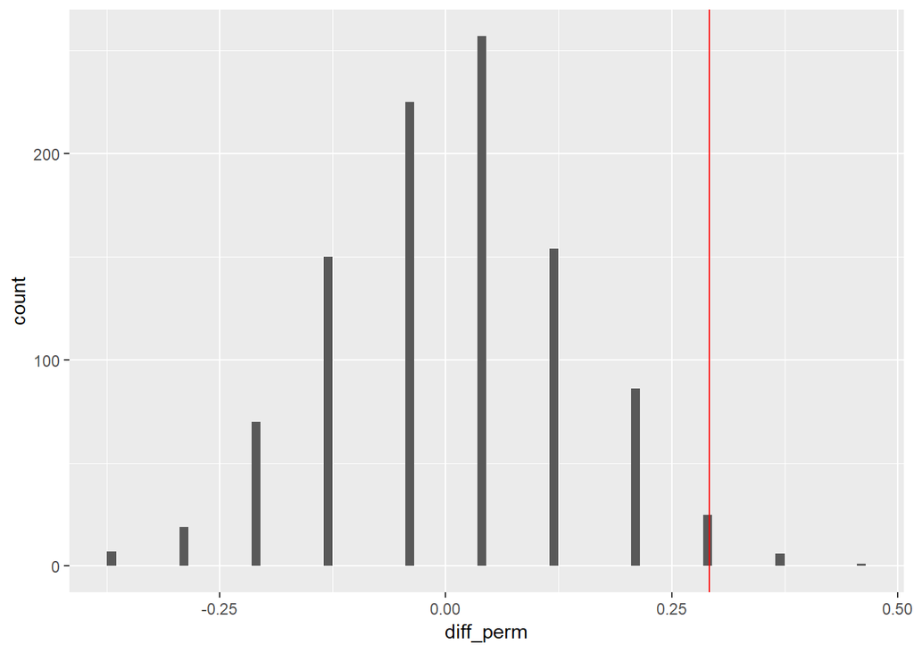

```r
# Create data frame of differences in admission rates
val_perm <- val %>%
  rep_sample_n(size = nrow(val), reps = 1000) %>%
  mutate(adm_perm = sample(admission))  %>%
  group_by(replicate, race) %>%
  summarize(prop_adm_perm = mean(adm_perm == "admitted"),
            prop_adm = mean(admission == "admitted")) %>%
  summarize(diff_perm = diff(prop_adm_perm),
            diff_orig = diff(prop_adm))  # white - black

library(ggplot2)
# Histogram of permuted differences
ggplot(val_perm, aes(x = diff_perm)) +
  geom_histogram(binwidth = 0.01) +
  geom_vline(aes(xintercept = diff_orig), col = "red")
```

Number of permuted difference greater than observed difference.

```r
(difference = val_perm %>%
  summarize(sum(diff_perm >= diff_orig)) %>% pull())
```

```
## [1] 32
```

```r
(difference / nrow(val_perm))*100
```

```
## [1] 3.2
```

### Using density

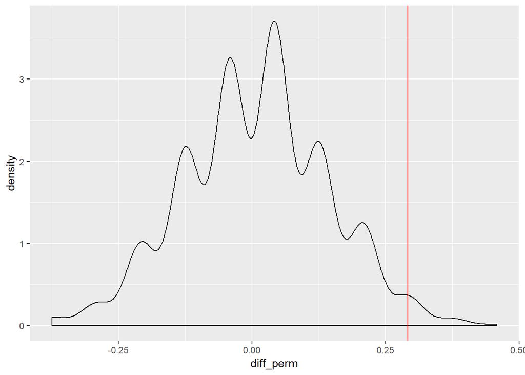

```r
ggplot(val_perm, aes(x = diff_perm)) +
  geom_density() +
  geom_vline(aes(xintercept = diff_orig), col = "red")
```

### Quantile measurement

```r
val_perm %>%
  summarize(q.05 = quantile(diff_perm, p = 0.05),
            q0.95 = quantile(diff_perm, p = 0.95))
```

```
## # A tibble: 1 x 2
##     q.05 q0.95
##    <dbl> <dbl>
## 1 -0.208 0.208
```

We see that observed difference of 0.29 is higher than 95% quantile of the null distribution indicating that htere is actually a difference in admission rate between races.

### Rejection region or critical region – the region where if our observed statistics fall we reject the null hypothesis

### P-value – the probability of observing statistic as or more extreme than what we got in the null distribution.

#### Can you figure out the p-value for val data for our case at hand?

### 2-sided p-value

In the previous example, if we were only interested to if there was any difference in admission due to race, we allow for the diferences to be positive sometimes and negative sometimes. Now, just due to random chance this differnce could sometimes be be positive and sometimes negative. Thus, we now need to consider both tail sides of the distribution. This will double the size of the p-value for two-side test than the p-value for one-side test.

#### p-value for 2-sided test of any difference in admission between races:

```r
(difference = val_perm %>%
  summarize(2 * mean(diff_perm >= diff_orig)) %>% pull())
```

```
## [1] 0.064
```

Normally, 5% is taken as standard p-value but we can also consider 1%.

### Now, we will study a case where some clients (50%) of Shwapno were chosen to be target for online advertising campaign (exclusive offers or as such) awareness program and some (50%) were not. All of these clients were grouped into similar class based on their purchase history. Now, after the campaign, we want to investigate whether this campaign had any positive effect in increasing purchase.

```r
promotions = read.csv("E:/Training_S/Day 4/promotion.csv")
str(promotions)
```

```
## 'data.frame':    200 obs. of  4 variables:
##  $ Promotion          : Factor w/ 2 levels "No","Yes": 2 2 2 2 2 2 2 2 2 2 ...
##  $ Additional.Purchase: Factor w/ 2 levels "More purchase",..: 1 1 1 1 1 1 1 1 1 1 ...
##  $ X                  : logi  NA NA NA NA NA NA ...
##  $ Satisfaction       : Factor w/ 2 levels "Happy","Not happy": 1 1 1 1 1 1 1 1 1 1 ...
```

#### Base R approach to tabulation

```r
table(promotions$Promotion, promotions$Additional.Purchase)
```

```
##
##       More purchase Same as before
##   No             21             79
##   Yes            40             60
```

#### dplyr approach to tabulation

```r
promotions %>%
  select(Promotion, Additional.Purchase) %>%
  table()
```

```
##          Additional.Purchase
## Promotion More purchase Same as before
##       No             21             79
##       Yes            40             60
```

#### Find the proportion of people who had additional purchase within each group (who got promotion and who didn’t)

```r
promotions %>%
  group_by(Promotion) %>%
  summarize(additional_prop = mean(Additional.Purchase == "More purchase"))
```

```
## # A tibble: 2 x 2
##   Promotion additional_prop
##   <fct>               <dbl>
## 1 No                   0.21
## 2 Yes                  0.4
```

Let’s create a barplot of purchase decision broken down by whether they were targetted for promotion or not.

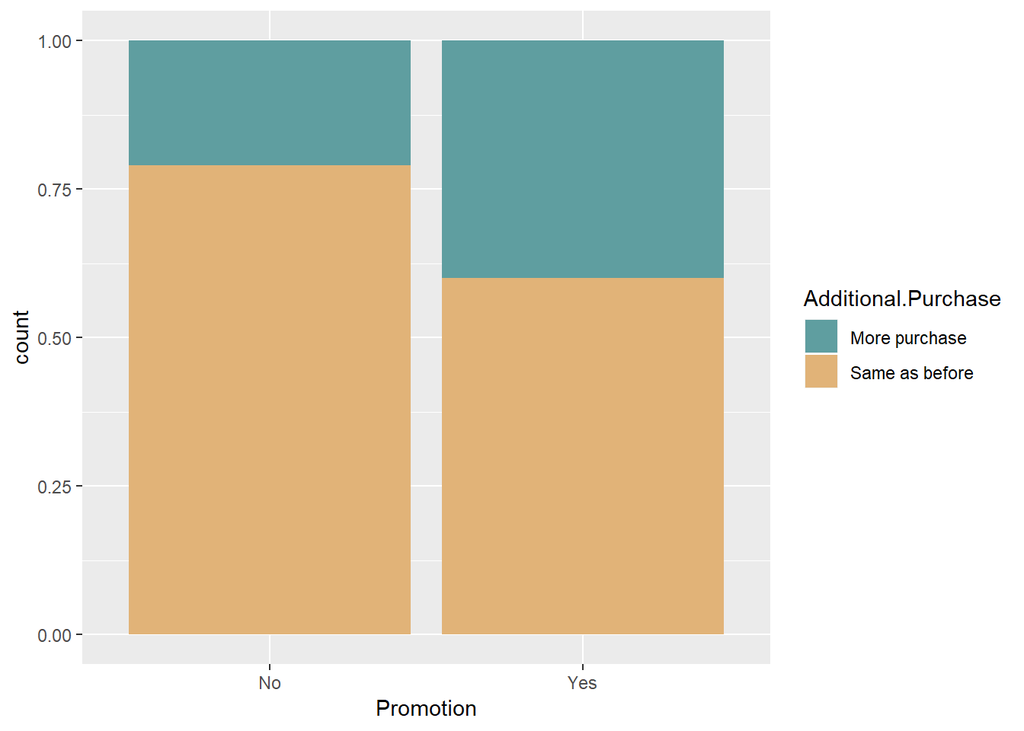

```r
library(RColorBrewer)
manual_fill = c("#5F9EA0", "#E1B378")
ggplot(promotions, aes(x=Promotion, fill = Additional.Purchase)) +
  geom_bar(position = "fill") +
  scale_fill_manual(values = manual_fill)
```

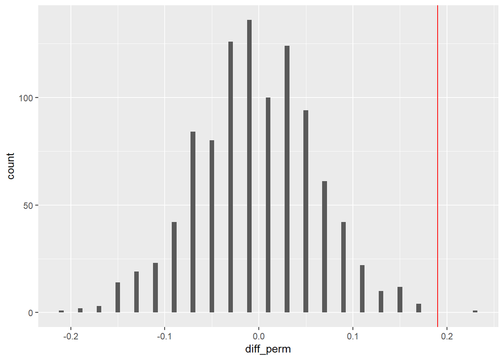

```r
prom_perm <- promotions %>%
  rep_sample_n(size = nrow(promotions), reps = 1000) %>%
  mutate(additional_perm = sample(Additional.Purchase)) %>%
  group_by(replicate, Promotion) %>%
  summarize(prop_purchase_perm = mean(additional_perm == "More purchase"),
            prop_purchase_orig = mean(Additional.Purchase == "More purchase")) %>%
  summarize(diff_perm = diff(prop_purchase_perm),
            diff_orig = diff(prop_purchase_orig))


# Histogram of permuted differences
ggplot(prom_perm, aes(x = diff_perm)) +
  geom_histogram(binwidth = .005) +
  geom_vline(aes(xintercept = diff_orig), col = "red")
```

Now, we will check to see if this observed difference in proportion is consistent with the null difference.

```r
prom_perm %>%
  summarize(mean(diff_perm >= diff_orig))
```

```
## # A tibble: 1 x 1
##   `mean(diff_perm >= diff_orig)`
##                            <dbl>
## 1                          0.001
```

### Confusion matrix

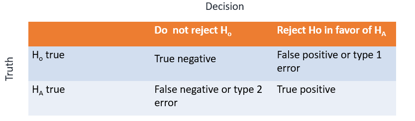

### Parameter vs. statistics

Parameter is a numerical value of some characteristics of the population. Statistics is a measure of this parameter using representative sample from the population.

### Standard error (SE)

SE of a statistic is the standard deviation of its sampling distribution.

### Confidence interval (CI)

Range of numbers that we hope with some confidence to represent the true parameter.

### Bootstrap

This let’s us measure how far the statistic is from the parameter by taking repeated sample with replacement from the sample and computing statistic for each of these samples. This gives us a bootstrap distribution. Using bootstrap we can get an approximation of the standard error.

### Empirical rule

Approximately 95% of samples will produce statistics that are within 2 SE of the center.

### 2-types of CI

- Bootstrap CI using empirical rule
- Percentile interval

### Now, we will focus on satifaction of customers. Let’s understand the proportion of satisfied customers.

#### Observed proportion

```r
(observed_proportion = promotions %>%
  summarize(mean(Satisfaction=="Happy")) %>%
  pull())
```

```
## [1] 0.61
```

#### Bootstrap distribution of proportion

```r
library(infer)
bootstrap = promotions %>%
  specify(response = Satisfaction, success = "Happy") %>%
  generate(reps = 300, type = "bootstrap") %>%
  calculate(stat = "prop")
bootstrap
```

```
## # A tibble: 300 x 2
##    replicate  stat
##        <int> <dbl>
##  1         1 0.63
##  2         2 0.635
##  3         3 0.61
##  4         4 0.64
##  5         5 0.585
##  6         6 0.675
##  7         7 0.675
##  8         8 0.62
##  9         9 0.59
## 10        10 0.55
## # ... with 290 more rows
```

Density plot of the bootstrap distribution

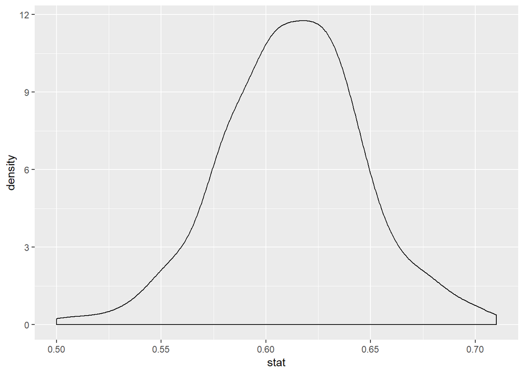

```r
ggplot(bootstrap, aes(x=stat)) +
  geom_density()
```

Standard deviation of this proportion

```r
(SE = bootstrap %>%
  summarize(sd(stat)) %>%
  pull())
```

```
## [1] 0.03391268
```

#### Confidence interval

```r
c(observed_proportion - 2 * SE, observed_proportion + 2 * SE)
```

```
## [1] 0.5421746 0.6778254
```

We are 95% confident that the proportion of all customers who are happy is between 0.54 and 0.67.

### Normal distribution for estimating SE

If observations are independent and n is large where n*p >= 10 and n(1-p) >= 10 then p follows a normal distribution where SE = root over of (p(1-p)/n). Here, p is p hat or estimation from the sample.

Let’s check whether the condition for applying normal approximation is met for observed_proportion.

```r
n = nrow(promotions)
c(n * observed_proportion, n * (1 - observed_proportion))
```

```
## [1] 122  78
```

As both are above 10, we can safely use normal approximation for calculating SE.

```r
(se_normal = sqrt(observed_proportion * (1 - observed_proportion) / n))
```

```
## [1] 0.03448913
```

And bootstrap method gave us

```r
bootstrap %>%
  summarize(sd(stat)) %>%
  pull()
```

```
## [1] 0.03391268
```

We can see that both of these two SE estimates are very close.

Now, let’s lay the sampling distribution of normal distribution of proportion on top of the bootstrap distribution.

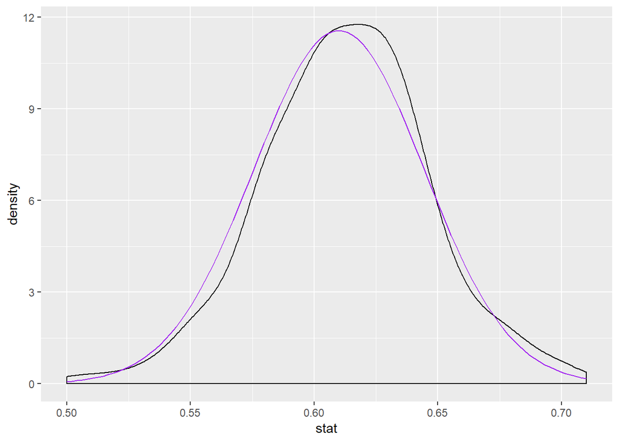

```r
ggplot(bootstrap, aes(x = stat)) +
  geom_density() +
  stat_function(fun = dnorm, color = "purple",
                args = list(mean = observed_proportion, sd = se_normal))
```

#### Hypothesis test for a particular value of proportion

Now, suppose we want to check whether the claim of 65% of the customers are happy are true or not.

```r
null_distribution = promotions %>%
  specify(response = Satisfaction, success = "Happy") %>%
  hypothesize(null = "point", p = 0.65) %>%
  generate(reps = 500, type = "simulate") %>%
  calculate(stat="prop")
```

How the observed proportion compares to null distribution?

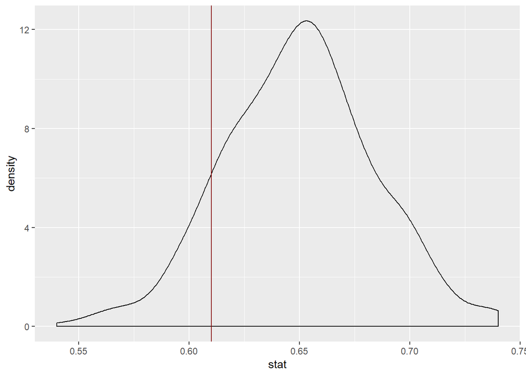

```r
ggplot(null_distribution, aes(x=stat)) +
  geom_density() +
  geom_vline(xintercept = observed_proportion, col = "darkred")
```

#### Computing p-value

```r
null_distribution %>%
  summarize(mean(stat < observed_proportion)) %>%
  pull() * 2
```

```
## [1] 0.204
```

### Difference in proportion – again

```r
null_dist = promotions %>%
  specify(Additional.Purchase ~ Promotion, success = "More purchase") %>%
  hypothesize(null ="independence") %>%
  generate(reps = 500, type = "permute") %>%
  calculate(stat = "diff in props", order = c("No", "Yes"))
```

#### Calculate p hat

```r
(prop = promotions %>%
  group_by(Promotion) %>%
  summarize(mean(Additional.Purchase == "More purchase")) %>%
  pull())
```

```
## [1] 0.21 0.40
```

#### Now calculate the observed difference in proportion

```r
(diff_prop = diff(prop))
```

```
## [1] 0.19
```

Let’s again plot the observed difference on the null distribution:

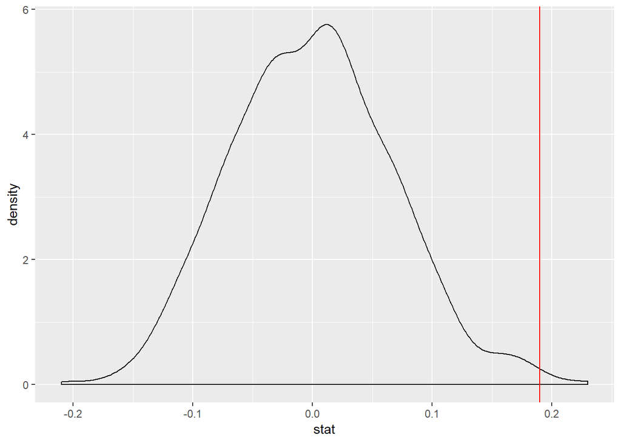

```r
ggplot(null_dist, aes(x=stat)) +
  geom_density() +
  geom_vline(xintercept = diff_prop, col = "red")
```

### P-value

```r
null_dist %>%
  summarize(mean(stat > diff_prop)) %>%
  pull() * 2
```

```
## [1] 0.004
```

### Comparing many categorical parameters

Is the geographical location associated with opinion towards freedom of press?

```r
opinion = read.csv("E:/Training_S/Day 4/opinion.csv")
str(opinion)
```

```
## 'data.frame':    480 obs. of  2 variables:
##  $ Location: Factor w/ 4 levels "East","North",..: 1 4 2 3 1 4 2 3 1 4 ...
##  $ Freedom : Factor w/ 4 levels "Low","Right",..: 4 2 1 3 2 1 2 1 3 2 ...
```

Let’s explore this visually:

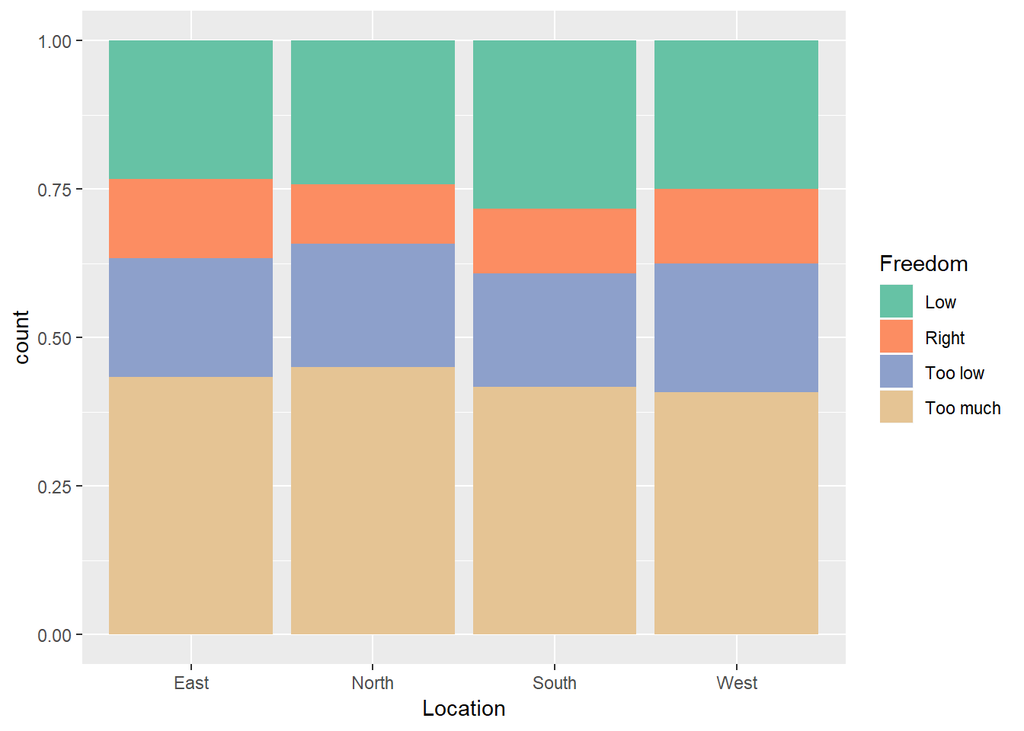

```r
ggplot(opinion, aes(Location, fill=Freedom)) +
  geom_bar(position = "fill") +
  scale_fill_manual(values = brewer.pal(8, "Set2")[c(1:3, 7)])
```

Let’s tabulate it now:

```r
(observed = opinion %>%
  table())
```

```
##         Freedom
## Location Low Right Too low Too much
##    East   28    16      24       52
##    North  29    12      25       54
##    South  34    13      23       50
##    West   30    15      26       49
```

Now, if the variables are independent of one another, we would have a null table of the counts of these observations, that is the table we would expect if the nvariables were independent of one annother. The total of squared difference between the observed cell count of the tabulation and the expected tabulation is called Chi-squared statistic.

We can compute the chi-squared statistic in R in the following way:

```r
(observed_chi = chisq.test(observed)$statistic)
```

```
## X-squared
##  1.892123
```

#### Generate null distribution for chi-square

```r
null_dist = opinion %>%
  specify(Freedom ~ Location) %>%
  hypothesize(null = "independence") %>%
  generate(reps = 500, type = "permute") %>%
  calculate(stat = "Chisq")
```

#### Plot observed Chi-square and the null distribution of Chi-square

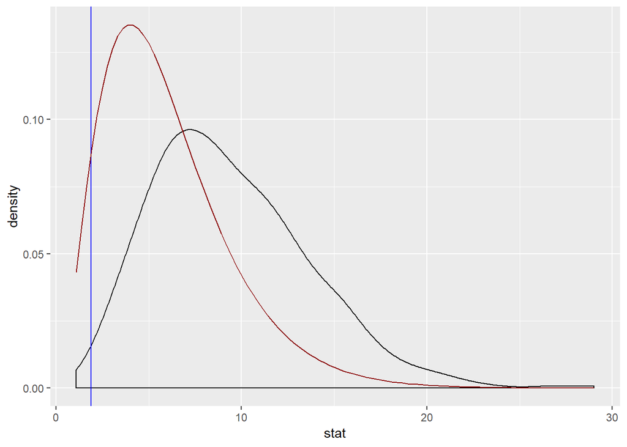

```r
ggplot(null_dist, aes(x = stat)) +
  geom_density() +
  geom_vline(xintercept = observed_chi, color = "blue") +
  stat_function(fun = dchisq, args = list(df = 6), color = "darkred")
```

#### P-value using permutation

```r
null_dist %>%
  summarize(mean(stat > observed_chi)) %>%
  pull()
```

```
## [1] 0.996
```

#### P-value using approximation

```r
1 - pchisq(observed_chi, df = 6)
```

```
## X-squared
## 0.9293478
```

Chi-squared distribution is a good approximation when expected count in each cell is greater than 5 and df is greater than or equal to 2.

### Inference for numerical data

#### Calculate confidence interval of mean

```r
income = read.csv("E:/Training_S/Day 4/income.csv")
str(income)
```

```
## 'data.frame':    104 obs. of  1 variable:
##  $ Income: int  3000 2000 4000 50000 8000 12000 90000 300000 100000 60000 ...
```

#### Generate null distribution of mean income

```r
mean_income_null = income %>%
  specify(response = Income) %>%
  generate(reps = 500, type = "bootstrap") %>%
  calculate(stat = "mean")
```

#### Observed mean

```r
obs_mean = income %>%
  summarize(mean(Income)) %>%
  pull()
```

#### Percentile method for CI

```r
mean_income_null %>%
  summarize(quantile(stat, 0.025),
            quantile(stat, 0.975))
```

```
## # A tibble: 1 x 2
##   `quantile(stat, 0.025)` `quantile(stat, 0.975)`
##                     <dbl>                   <dbl>
## 1                  69766.                 105059.
```

#### Standard error method for CI

sample statistic +/- t * standard error of bootstrap distribution

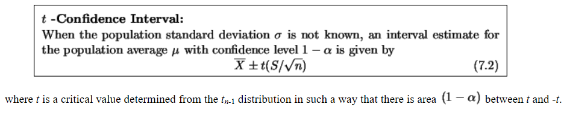

#### Critical value of t

```r
t_critical = qt(0.975, df = nrow(income) - 1)
```

#### CI using SE

```r
mean_income_null %>%
  summarize(null_se = sd(stat)) %>%
  summarize(low = obs_mean - t_critical * null_se,
            high = obs_mean + t_critical * null_se)
```

```
## # A tibble: 1 x 2
##      low    high
##    <dbl>   <dbl>
## 1 66680. 104089.
```

#### Can you do it for median?

#### Someone claims that the average income is 120000, test it.

```r
point_income_null = income %>%
  specify(response = Income) %>%
  hypothesize(null = "point", mu = 120000) %>%
  generate(reps = 1000, type = "bootstrap") %>%
  calculate(stat = "mean")
head(point_income_null)
```

```
## # A tibble: 6 x 2
##   replicate    stat
##       <int>   <dbl>
## 1         1 120635.
## 2         2 143885.
## 3         3 116154.
## 4         4 129029.
## 5         5 115183.
## 6         6 105615.
```

```r
# Calculate observed mean
mean_obs_inc <- income %>%
  summarize(mean(Income)) %>%
  pull()

# Calculate p-value
point_income_null %>%
  filter(mean_obs_inc < stat) %>%
  summarize(n() / 1000)
```

```
## # A tibble: 1 x 1
##   `n()/1000`
##        <dbl>
## 1          1
```

#### Confidence interval of mean income

```r
t.test(income$Income, conf.level = 0.95)
```

```
##
##  One Sample t-test
##
## data:  income$Income
## t = 8.8038, df = 103, p-value = 3.345e-14
## alternative hypothesis: true mean is not equal to 0
## 95 percent confidence interval:
##   66149.68 104619.55
## sample estimates:
## mean of x
##  85384.62
```

#### Confidence interval of mean difference in paired data

```r
paired = read.csv("E:/Training_S/Day 5/paired.csv")
str(paired)
```

```
## 'data.frame':    41 obs. of  2 variables:
##  $ val1: int  20 30 40 50 34 56 34 67 45 67 ...
##  $ val2: int  120 140 160 170 140 190 120 187 150 145 ...
```

Calculate difference between val1 and val2

```r
paired = paired %>%
  mutate(difference = val2 - val1)
glimpse(paired)
```

```
## Observations: 41
## Variables: 3
## $ val1       <int> 20, 30, 40, 50, 34, 56, 34, 67, 45, 67, 23, 45, 67,...
## $ val2       <int> 120, 140, 160, 170, 140, 190, 120, 187, 150, 145, 1...
## $ difference <int> 100, 110, 120, 120, 106, 134, 86, 120, 105, 78, 131...
```

#### Confidencce interval for mean difference

```r
t.test(paired$difference, conf.level = 0.95)
```

```
##
##  One Sample t-test
##
## data:  paired$difference
## t = 35.351, df = 40, p-value < 2.2e-16
## alternative hypothesis: true mean is not equal to 0
## 95 percent confidence interval:
##  100.2158 112.3695
## sample estimates:
## mean of x
##  106.2927
```

#### Testing mean

H0: There is no difference between average value of val1 and val2 H1: There is a difference between average value of val1 and val2

```r
t.test(paired$difference, null = 0, alternative = "two.sided")
```

```
##
##  One Sample t-test
##
## data:  paired$difference
## t = 35.351, df = 40, p-value < 2.2e-16
## alternative hypothesis: true mean is not equal to 0
## 95 percent confidence interval:
##  100.2158 112.3695
## sample estimates:
## mean of x
##  106.2927
```

Now, let’s check how it differs from bootstrap calculation

```r
paired_boot = paired %>%
  specify(response = difference) %>%
  generate(reps = 10000, type="bootstrap") %>%
  calculate(stat="mean")
```

95% confidence interval

```r
paired_boot %>%
  summarize(lower = quantile(stat, 0.025),
            upper = quantile(stat, 0.975))
```

```
## # A tibble: 1 x 2
##   lower upper
##   <dbl> <dbl>
## 1  101.  112.
```

#### P-value for mean difference using bootstrap

```r
paired_boot_test = paired %>%
  specify(response = difference) %>%
  hypothesize(null = "point", mu = 0) %>%
  generate(reps = 10000, type  = "bootstrap") %>%
  calculate(stat = "mean")
```

#### Observed mean difference

```r
mean_observed_diff = paired %>%
  summarize(mean(difference)) %>%
  pull()
```

#### P-value

```r
paired_boot_test %>%
  filter(stat > mean_observed_diff) %>%
  summarize(2 * n() / 10000)
```

```
## # A tibble: 1 x 1
##   `2 * n()/10000`
##             <dbl>
## 1               0
```

#### Comparing two means from two independent distributions

Suppose, Shwapno wants to increase its online shopping revenue. Executives from Shwapno has come up with two different schemes A nd B for this. When users of Shwapno access its website, they are randomly assigned to one of these schemes. That is, some users access Shwapno website refurbished with scheme 1 and some users access Shwapno website with scheme 2.There is also information system which records the time an user expends in browsing the website. Further assume that for this study, we consider only those users who have already used Shwapno online or at least browsed Shwapno and there are records of their activity time in Shwapno’s data storage. Now, Shwapno wants to know whether scheme B helps more to increse user’s online activity at Shwapno’s website than the scheme A does.

Let’s load the data first.

```r
scheme = read.csv("E:/Training_S/Day 5/scheme.csv")
head(scheme)
```

```
##   scheme before after
## 1      A    120   210
## 2      A    140   160
## 3      A    160   170
## 4      A    170   180
## 5      A    140   140
## 6      A    190   191
```

First calculate the difference in user experience time

```r
scheme = scheme %>%
  mutate(change = after - before)
```

Observed difference in means

```r
(observed_diff = scheme %>%
  group_by(scheme) %>%
  summarize(mean_diff = mean(change)) %>%
  pull() %>%
  diff())
```

```
## [1] 60.7
```

Using randomization to generate the null distribution of difference in means

```r
mean_bootstrap_difference = scheme %>%
  specify(change ~ scheme) %>%
  hypothesize(null = "independence") %>%
  generate(reps = 10000, type="permute") %>%
  calculate(stat = "diff in means", order = c("B", "A"))
```

#### P-value

```r
mean_bootstrap_difference %>%
  filter(stat > observed_diff) %>%
  summarize(n() / 10000)
```

```
## # A tibble: 1 x 1
##   `n()/10000`
##         <dbl>
## 1    0.000300
```

We can conclude that scheme B is more effective than scheme A.

#### t-test for comparing means

```r
t.test(change ~ scheme, data = scheme)
```

```
##
##  Welch Two Sample t-test
##
## data:  change by scheme
## t = -4.2612, df = 26.7, p-value = 0.0002253
## alternative hypothesis: true difference in means is not equal to 0
## 95 percent confidence interval:
##  -89.94328 -31.45672
## sample estimates:
## mean in group A mean in group B
##           16.95           77.65
```

### ANOVA – Comparing many means

H0: The mean of a numeric variable is the same across all classes under consideration HA: The mean of this numeric variable is different between at least one of the classes

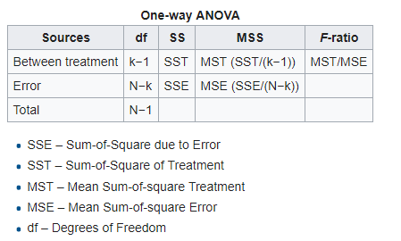

#### Conditions for ANOVA

- **Independence:** observations have to be independent, classes have to be independent also
- **Approximate normality:** response variable needs to be nearly normal within each class
- **Equal variance:** Groups need to have more or less equal variance, homoscedasticity

```r
results = data.frame(group=c(rep("A", 100), rep("B", 120), rep("C", 150), rep("D", 130)),
                     value = c(rnorm(100, 200, 20), rnorm(120, 189, 22), rnorm(150, 230, 24), rnorm(130, 196, 22)))
```

```r
library(broom)
(model = aov(value ~ group, results) %>%
  tidy())
```

```
## # A tibble: 2 x 6
##   term         df   sumsq meansq statistic   p.value
##   <chr>     <dbl>   <dbl>  <dbl>     <dbl>     <dbl>
## 1 group         3 136732. 45577.      84.7  3.04e-44
## 2 Residuals   496 267016.   538.      NA   NA
```

This says that there are differences in means but not among which. We can determine the groups that have differences using **TukeyHSD**

TukeyHSD test controls for type 1 error.

```r
TukeyHSD(aov(value ~ group, results))
```

```
##   Tukey multiple comparisons of means
##     95% family-wise confidence level
##
## Fit: aov(formula = value ~ group, data = results)
##
## $group
##           diff        lwr         upr     p adj
## B-A  -7.632848 -15.731101   0.4654044 0.0728996
## C-A  32.468421  24.747040  40.1898020 0.0000000
## D-A  -1.320847  -9.276262   6.6345683 0.9736686
## C-B  40.101269  32.776124  47.4264143 0.0000000
## D-B   6.312001  -1.259435  13.8834382 0.1392684
## D-C -33.789268 -40.956184 -26.6223520 0.0000000
```